# Intro to Probability via Simulation

Mon Oct 31, 2016

## Recall

Recall from last lecture we studied

- **Random** sampling: where we select the sample from the population in an unbiased fashion
- Bias: A sample is biased if some observational units have a higher **probability** of being included in the sample.

Keywords: **random** and **probability**

## Probability

- In short: probability is the study of randomness.
- The study of probability lies in one [historical constant](https://www.google.com/search?q=probability&newwindow=1&source=lnms&tbm=isch&sa=X&ved=0ahUKEwjnvJG7_oTQAhVIQiYKHSQ7CnoQ_AUICSgC&biw=2559&bih=1316&dpr=2#newwindow=1&tbm=isch&q=history+of+gambling).

## Two Approaches to Probability

There are two way to approaches to studying probability:

Mathematically (MATH 310)

Simulations

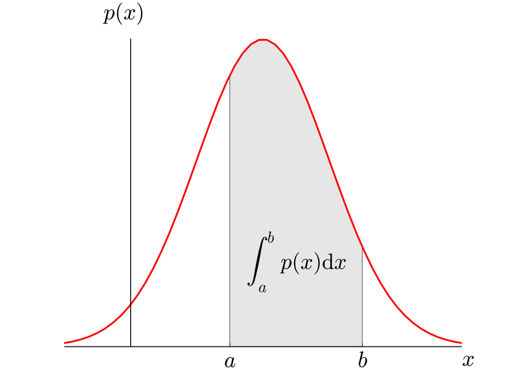

## Simulations via Computer

- The mathematical approach to studying probability requires more mathematical background: set theory, discrete math, calculus, and later on measure theory.
- The [simulation approach](http://rpruim.github.io/eCOTS2014/Workshop/ResamplingPres.html) does not, but requires a computer's **random number generator** to generate simulations. Why?

## Critical Note

The "random simulation" in question is not limited to coin flips.

## Analogy for Random Simulation

For **any** random simulation, think to this: POWERBALL

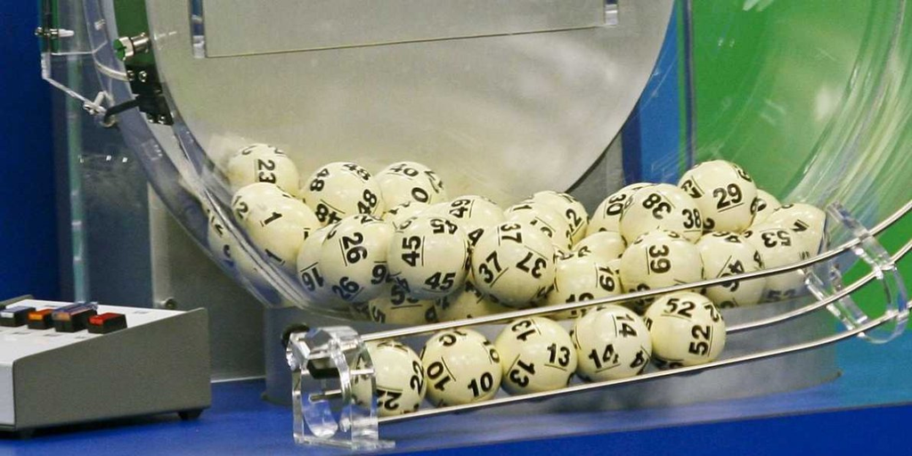

## Analogy for Random Simulation

Different simulations can be set by varying the attributes of the Powerball lottery:

- Balls:
  - How many balls do you have?
  - What are written on the balls?
  - Do the balls have equal probability of being picked?
- Drawing balls at random
  - How many balls do you pick?
  - What do you do with a ball after you've picked/recorded it?
- Number of lotteries
  - How many times do you repeat the lottery?

## Analogy for Random Simulation

[output not shown]

```
##
## Flipping 1 coin [ Prob(Heads) = 0.5 ] ...
##
## H
##
## Number of Heads: 1 [Proportion Heads: 1]
```

```
##
## Flipping 10 coins [ Prob(Heads) = 0.5 ] ...
##
## H T H H T T H H T T
##
## Number of Heads: 5 [Proportion Heads: 0.5]
```

```
## # A tibble: 10 × 4
##        n heads tails  prop
##    <dbl> <dbl> <dbl> <dbl>
## 1     10     7     3   0.7
## 2     10     6     4   0.6
## 3     10     3     7   0.3
## 4     10     8     2   0.8
## 5     10     6     4   0.6
## 6     10     6     4   0.6
## 7     10     4     6   0.4
## 8     10     6     4   0.6
## 9     10     6     4   0.6
## 10    10     2     8   0.2
```

```
## # A tibble: 6 × 2
##   heads count
##   <dbl> <int>
## 1     2     1
## 2     3     1
## 3     4     1
## 4     6     5
## 5     7     1
## 6     8     1
```

```
##   n heads tails prop
## 1 1     0     1    0
## 2 1     1     0    1
## 3 1     0     1    0
```

```
##   V1 V2 V3 V4 V5 V6
## 1  6  3  4  6  5  1
## 2  1  5  2  4  5  2
## 3  1  3  6  2  6  4
```

```
##   V1 V2 V3 V4 V5 V6
## 1  2  5  6  1  3  4
## 2  1  5  4  6  2  3
## 3  6  2  4  1  5  3
```